# STSCI 4060 - Lecture 11

Python, Database-Driven Web Pages, and SAS

Harry Lu

# 1 Our Scenario

- Collect data of interest from internet.
- Study the data collected.
- Treat/transform the data with Python programs.
- Store the transformed data in an Oracle database through a network using Python.
- Access the database through a network using Python, which is an example of **database-driven**, **Python-powered** dynamic webpage.
- Analyze the data stored in the database with SAS, etc.

# 2 Gather Our Data of Interest

- Honey bee proteins that have been discovered and studied.
- Available from the Internet, especially from NCBI (http://www.ncbi.nlm.nih.gov/)

# 3 The Honey Bee Protein Data Set

- Link: https://www.ncbi.nlm.nih.gov/protein/NP_001011578.1?report=fasta

## 3.1 Inspect The Honey Bee Protein Data Set

- An entry (protein) always starts with `>gi|` (in our case).
- It starts with a short description about the protein, but the length varies.
- There is a substring `[Apis mellifera]` right before the actual protein sequence.
- The sequence has a **carriage return** at the end of each line of the sequence.
- Our interest:
  - Only interested in one species of honey bees, **Apis mellifera**
  - The **gi number** (which can be used as a protein ID)
  - The continuous **protein sequence**
  - The **relative frequency** of the amino acids in each protein

# 4 Our Plan to Treat the Data Set

- Use Python as the programming tool
- Submit this data file to the database (Oracle) through a specific web page
- Read in the content as a string
- Change content into a continuous string
- Split the string into a list of bee proteins that only belong to **Apis mellifera**
- Extract the **gi number** and the **sequence** of each protein
- Calculate the **relative frequencies** of the 20 amino acids
- Store the data/information in the Oracle database through a network

# 5 Design a Web Page to Upload the Data

[figure not shown]

# 6 Python Coding: the General Algorithm

- Code two CGI (common gateway interface) files, one for reading and processing data and one for displaying database contents.
- Use Python functions to achieve the goal: `main()`, `processInput()`, …
- The `main()` function receives the file name from the web page and pass it to the `processInput()` function and finally display the results on a web page.
- The `processInput()` function creates a new database table in Oracle, reads and processes the data as planned earlier. More details on database handling: Use special features (e.g., `>gi|`, `[Apis mellifera]`) of the dataset to extract the gi numbers and protein sequences:
  - Use bind variables to populate the database table.
  - Write other functions when necessary, e.g., `fileToStr()` and `makePage()`.
- Design two webpage templates, one to confirm uploading data to the database and one to display some contents retrieved from the database.

# 7 Slice out the Sub-strings of Interest from the String Containing the Bee Protein Data

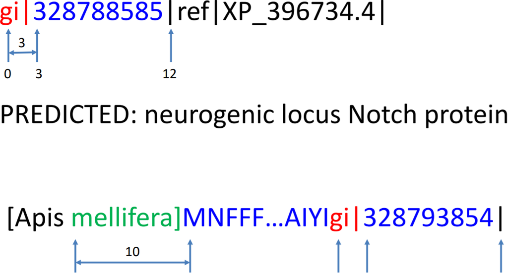

# 8 The 1st CGI File

```python
'''
This program processes the data file uploaded by the user through a network and saves the processed data to an Oracle database.

******** Coded by Xiaolong Yang @ Cornell University ********
'''

import cgi
import cx_Oracle

def main(): # NEW
    form = cgi.FieldStorage() # cgi script line
    theStr = form.getfirst("theList", "")
    contents = processInput(theStr)
    print contents

def processInput(theFile):
    '''This function reads the bee protein data from a raw data file and extract the gi number values and the protein sequences. Then, the relative frequencies of the amino acids are calculated for each protein. A new Oracle database table is created using Python and is populated with the data created.'''

    con = cx_Oracle.connect("python/welcome")
    cur = con.cursor()
    cur.execute("drop table beeProteins")
    cur.execute('''create table beeProteins (
                    gi varchar2(10),
                    sequence clob,
                    freq_A number,
                    freq_R number,
                    freq_N number,
                    freq_D number,
                    freq_C number,
                    freq_Q number,
                    freq_E number,
                    freq_G number,
                    freq_H number,
                    freq_I number,
                    freq_L number,
                    freq_K number,
                    freq_M number,
                    freq_F number,
                    freq_P number,
                    freq_S number,
                    freq_T number,
                    freq_W number,
                    freq_Y number,
                    freq_V number
                    )''')

    cur.bindarraysize = 50
    cur.setinputsizes(10, 9000, float, float, float, float, float, float, float, float, float, float, float, float, float, float, float, float, float, float, float, float)

    # read raw data from a file
    infile = file(theFile, "r")
    myStr = ""
    finalStr = ""

    # form a string with the raw data
    for aline in infile:
        myStr = myStr + aline

    # form a continuous string
    strL = myStr.replace("\n", "")

    # change the string into a list, one protein per list item
    aList = strL.split(">")

    # keep the list items that contains the substring, [Apis mellifera]
    for anItem in aList:
        if "[Apis mellifera]" in anItem:
            finalStr = finalStr + anItem

    end = 0
    totalLength = len(finalStr)
    repetitions = finalStr.count("[Apis mellifera]")

    # extract the target substrings, the gi number and the protein sequence
    for i in range(repetitions):

        start = finalStr.find("gi|", end) + 3
        end = finalStr.find("|", start)
        gi = finalStr[start:end]
        # print "gi =", gi
        start = finalStr.find("mellifera]", end) + 10
        end = finalStr.find("gi|", start)
        if end == -1:
            end = totalLength
        seq = finalStr[start:end]
        # print "seq =", seq
        seqLength = len(seq)
        freq_A = seq.count("A")/float(seqLength)
        freq_R = seq.count("R")/float(seqLength)
        freq_N = seq.count("N")/float(seqLength)
        freq_D = seq.count("D")/float(seqLength)
        freq_C = seq.count("C")/float(seqLength)
        freq_Q = seq.count("Q")/float(seqLength)
        freq_E = seq.count("E")/float(seqLength)
        freq_G = seq.count("G")/float(seqLength)
        freq_H = seq.count("H")/float(seqLength)
        freq_I = seq.count("I")/float(seqLength)
        freq_L = seq.count("L")/float(seqLength)
        freq_K = seq.count("K")/float(seqLength)
        freq_M = seq.count("M")/float(seqLength)
        freq_F = seq.count("F")/float(seqLength)
        freq_P = seq.count("P")/float(seqLength)
        freq_S = seq.count("S")/float(seqLength)
        freq_T = seq.count("T")/float(seqLength)
        freq_W = seq.count("W")/float(seqLength)
        freq_Y = seq.count("Y")/float(seqLength)
        freq_V = seq.count("V")/float(seqLength)

        cur.execute('''insert into beeProteins (gi, sequence, freq_A, freq_R, freq_N, freq_D, freq_C, freq_Q, freq_E, freq_G, freq_H, freq_I, freq_L, freq_K, freq_M, freq_F, freq_P, freq_S, freq_T, freq_W, freq_Y, freq_V) values(:v1, :v2, :v3, :v4, :v5, :v6, :v7, :v8, :v9, :v10, :v11, :v12, :v13, :v14, :v15, :v16, :v17, :v18, :v19, :v20, :v21, :v22)''', (gi, seq, freq_A, freq_R, freq_N, freq_D, freq_C, freq_Q, freq_E, freq_G, freq_H, freq_I, freq_L, freq_K, freq_M, freq_F, freq_P, freq_S, freq_T, freq_W, freq_Y, freq_V))

    con.commit()

    cur.close()
    con.close()

    return makePage("done_submission_Template.html", ("Thank you for uploading."))

def fileToStr(fileName):
    '''Return a string containing the contents of the named file.'''
    fin = open(fileName);
    contents = fin.read();
    fin.close()
    return contents

def makePage(templateFileName, substitutions):
    pageTemplate = fileToStr(templateFileName)
    return pageTemplate % substitutions

try:
    print "Content-type: text/html\n\n"
    main()
except:
    cgi.print_exception()
```

# 9 The Confirmation Page Template

[figure not shown]

# 10 The 2nd CGI File

```python
'''
This program extracts the data from the Oracle database and display them on a web page upon user request.

******** Coded by Xiaolong Yang @ Cornell University ********
'''

import scipy as sp
import cgi
import cx_Oracle

def main(): # NEW
    # form = cgi.FieldStorage() # cgi script line
    # theStr = from.getfirst("theList", "")
    contents = processInput()
    print contents

def processInput(): # This function extracts data from a Oracle table.
    con = cx_Oracle.connect("python/welcome")
    cur = con.cursor()
    aaList = ["A", "R", "N", "D", "C", "Q", "E", "G", "H", "I", "L", "K", "M", "F", "P", "S", "T", "W", "Y", "V"]
    fList = [() for t in range(20)]
    for i in range(20):
        myDict = {"aa":aaList[i]}
        obj = cur.execute('''select gi, freq_%(aa)s from beeproteins, (select max(freq_%(aa)s) as max%(aa)s from beeproteins) where freq_%(aa)s = max%(aa)s''' % myDict)
        for x in obj:
            fList[i] = x

    myTuple = ()
    for t in range(20):
        myTuple = myTuple + fList[t]

    cur.close()
    con.close()

    return makePage("see_result_template.html", myTuple)

def fileToStr(fileName):
    '''Return a string containing the contents of the named file.'''
    fin = open(fileName);
    contents = fin.read();
    fin.close()
    return contents

def makePage(templateFileName, substitutions):
    pageTemplate = fileToStr(templateFileName)
    return pageTemplate % substitutions

try:
    print "Content-type: text/html\n\n"
    main()
except:
    cgi.print_exception()
```

# 11 The Database-Driven Webpage Template: the Design View

`see_result_template.html`:

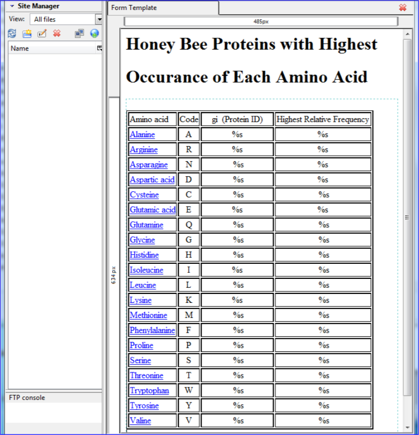

# 12 User uploads a data file for processing

[figure not shown]

# 13 Feedback: Successful data uploading and processing

[figure not shown]

# 14 The Result of Database-driven, Python-control Webpage

[figure not shown]

# 15 Analyze the Data Uploaded, Processed and Stored in the Oracle Database

## 15.1 Display a DB Table in SAS

```sas
libname beeprot oracle user = "python" password = "welcome" path = "xe";
PROC PRINT data = beeprot.beeproteins;
RUN;
```

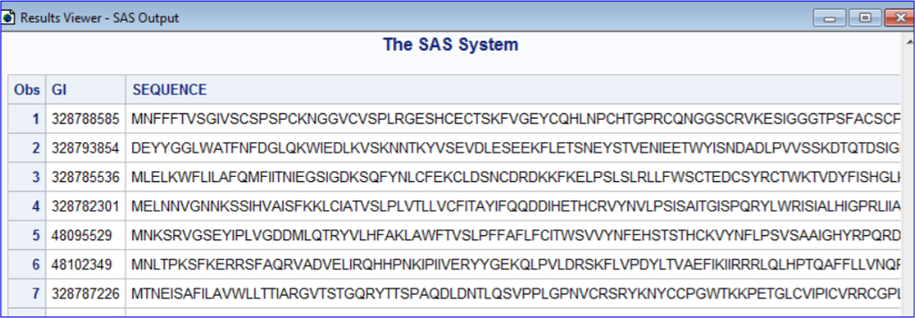

## 15.2 Cluster Analysis in SAS

```sas
libname beeprot oracle user = "python" password = "welcome" path = "xe";
PROC CLUSTER data = beeprot.beeproteins method = ward ccc pseudo outtree = tree;
  var freq_A freq_R freq_N freq_D freq_C freq_Q freq_E freq_G freq_H freq_I freq_L freq_K freq_M freq_F freq_P freq_S freq_T freq_W freq_Y freq_V;
RUN;
```

## 15.3 Diagrams of CCC, PST2 and PSF

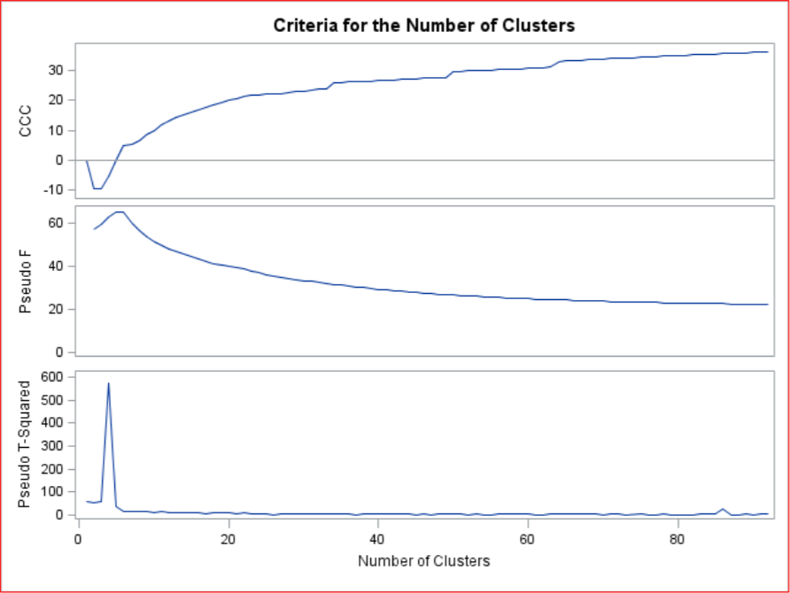

## 15.4 Cluster Analysis Results: Values of CCC, PST2 and PSF

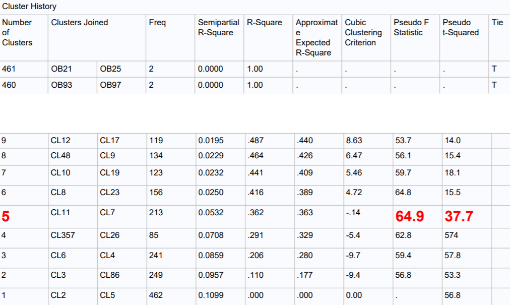

## 15.5 The Dendrogram

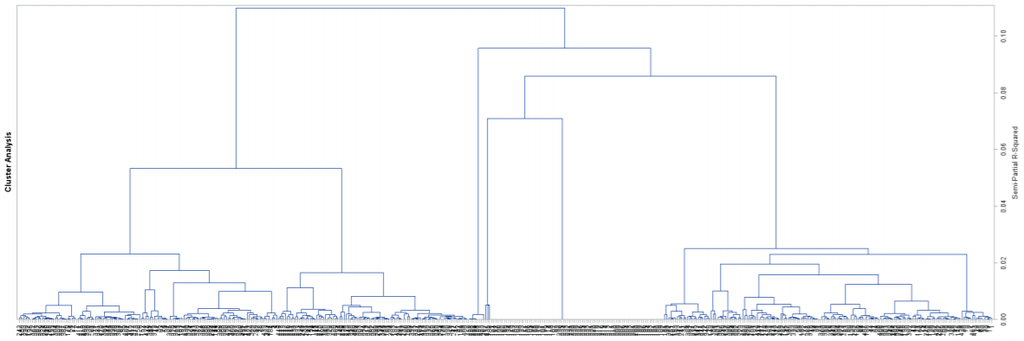